# From zero to hero: raw data to mapped networks - 7 Cytoscape

download all materials

##### The following example will detail how to use the exported `DAVe` analysis results to create a publicastion quality network using [Cytoscape](https://cytoscape.org/).

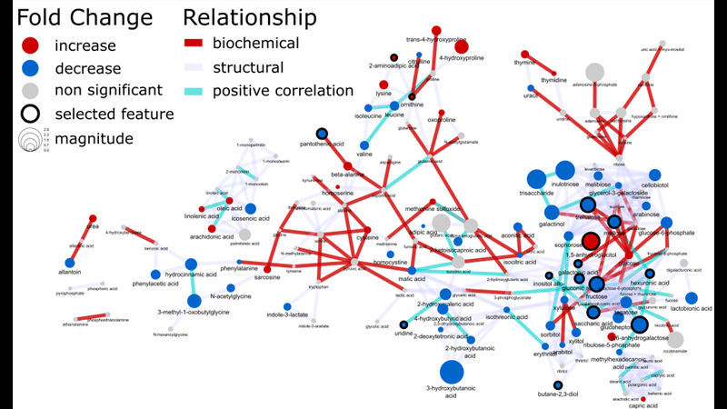

### Import

##### Use the [data] {.txbox_green} module to export (save) the selected network `nodes` and `edges`.

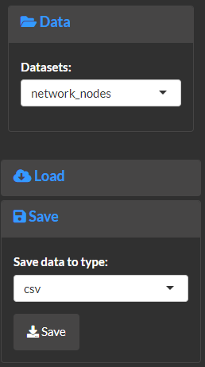

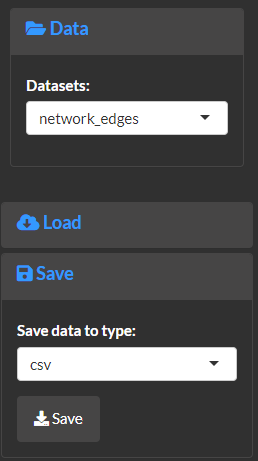

##### Use [Cytoscape](https://cytoscape.org/) to create a publication quality network from the exported `node` and `edge` data.

##### Import the `edge` data.

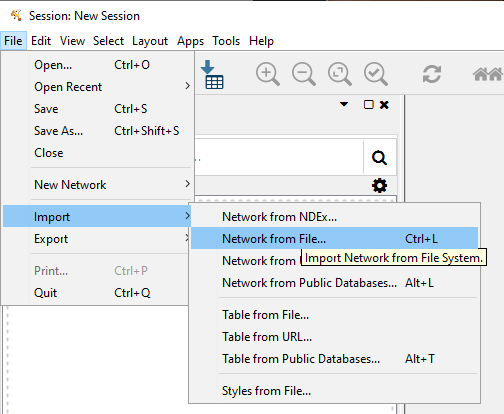

##### Specify the `source` and `target` nodes as the `from` and `to` columns in the `edges` data.

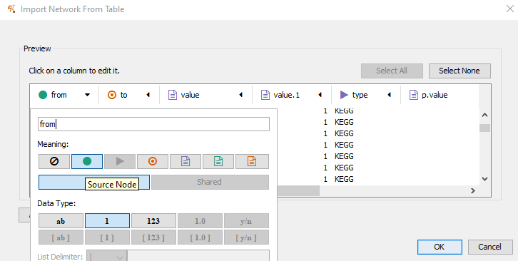

##### After selecting `OK` you should see the resulting network.

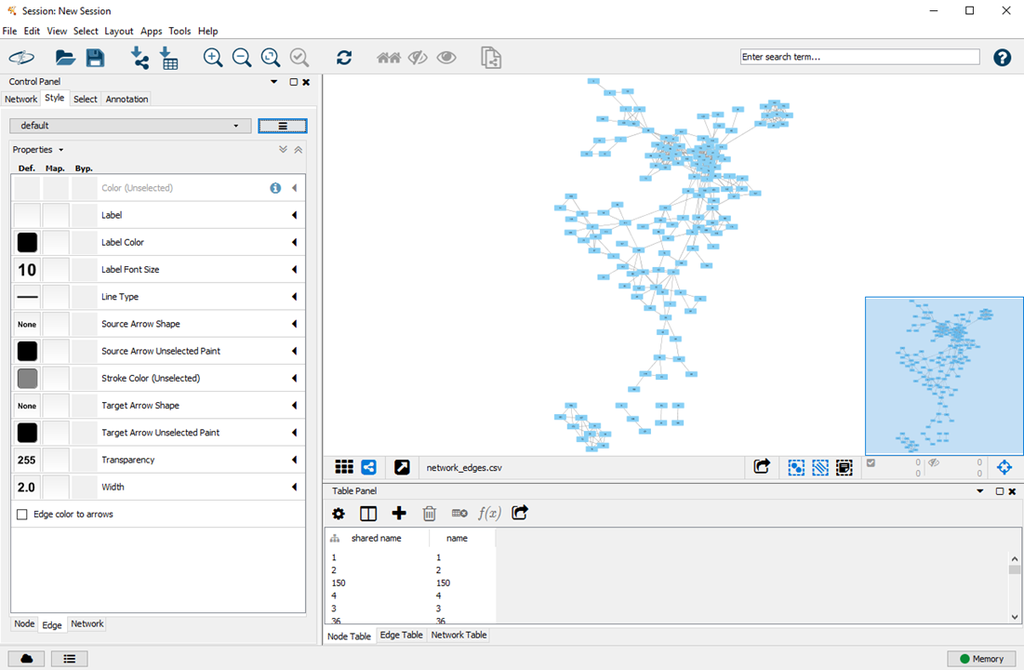

##### Next load the `node` data.

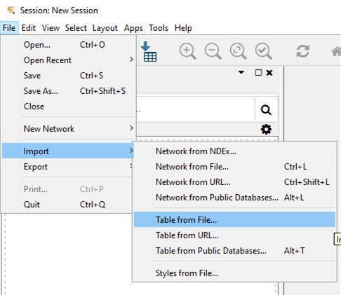

##### The `node` data should be set as the `id`. Some of the variables like `name` may conflict with `cytoscape` select these and rename them (e.g. rename `name` to `label`).

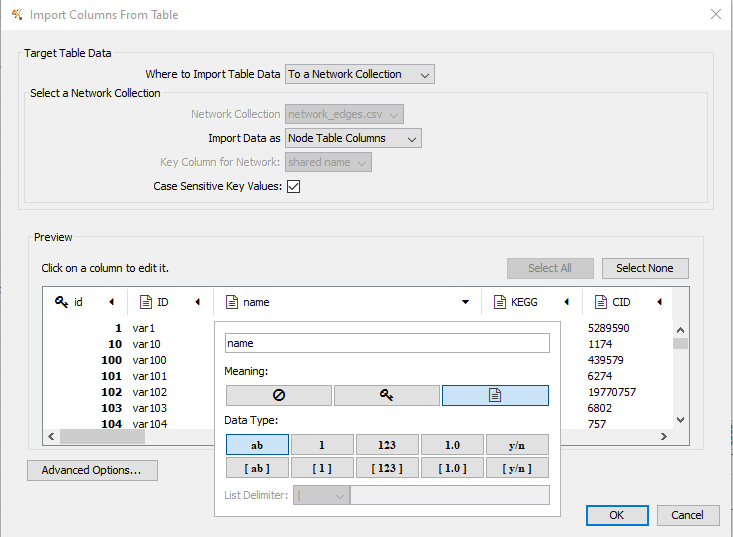

##### After selecting `OK` you should now be able to view the imported `node` data (right bottom panel `tab panel`, `node table`).

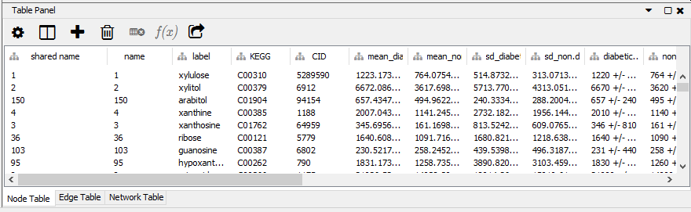

### Style network

##### Modify the global network setting by selecting a template in the `style` menu.

[figure not shown]

##### This will style the network as shown below.

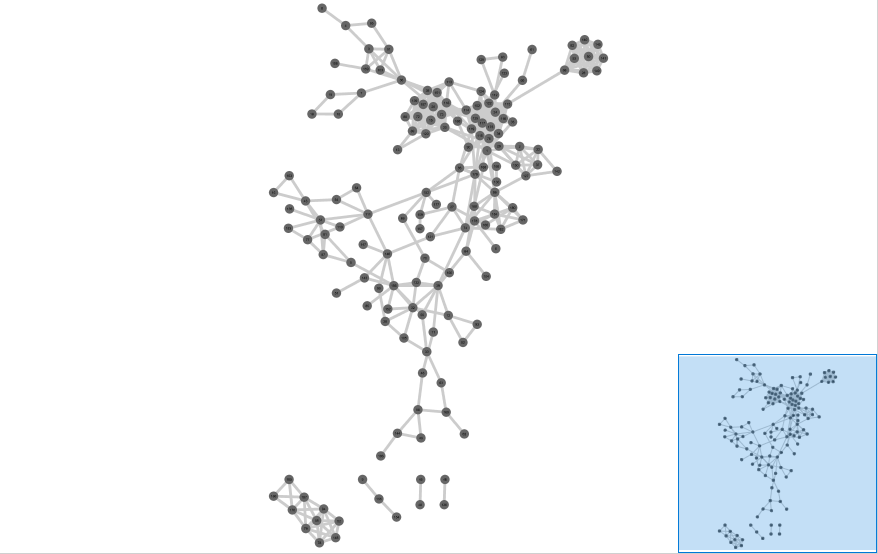

##### Next map the `edge` data to network `edge` aesthetics. The settings below display how to map edge color and transparency based on the network `type`.

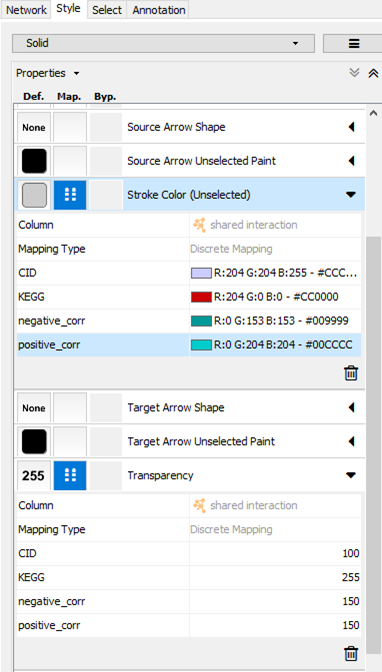

##### These mappings will style the network as shown below.

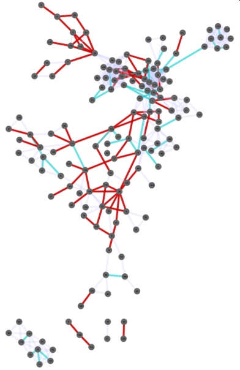

[figure not shown]

##### The following shows how to specify the node label text and font size.

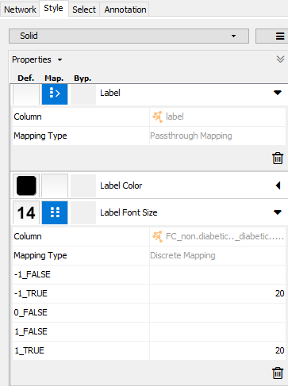

##### The following shows how to alter node size based on the magnitude of the fold change.

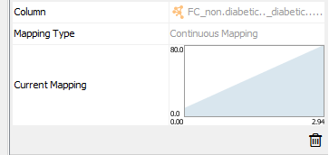

##### After the node mapping is completed the mapped networked should be styled as the image shown below.

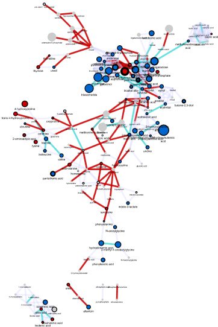

### Fine-tune network

##### Next use the node layout tools to optimize the network layout.

##### Select the `node layout tools`.

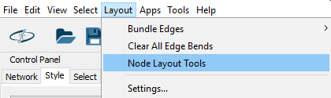

##### Scale and rotate the network as needed. Note you can click and drag to select specific nodes to alter.

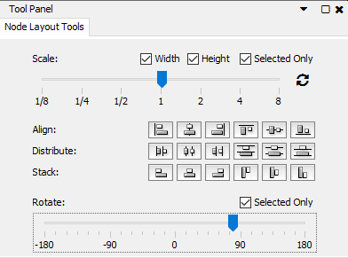

##### Next use the [legend creator](https://apps.cytoscape.org/apps/legendcreator) plugin to generate the network legend.

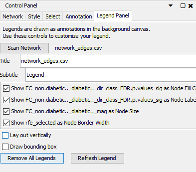

##### After some fine-tuning the final network is shown below.

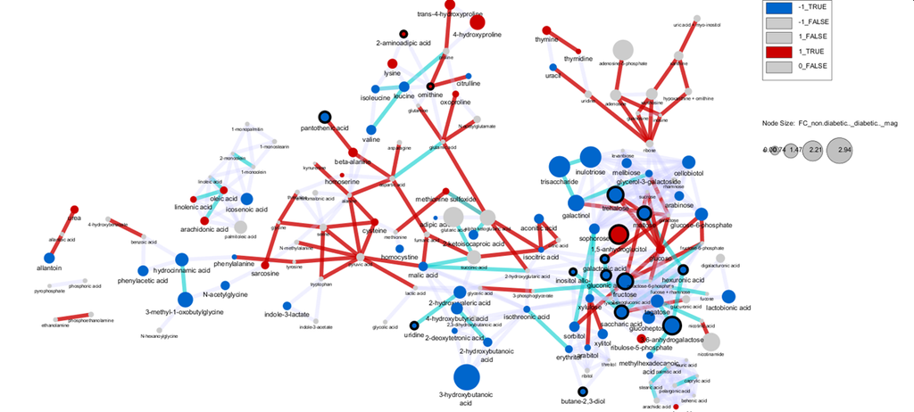

##### Now the network is ready for export.

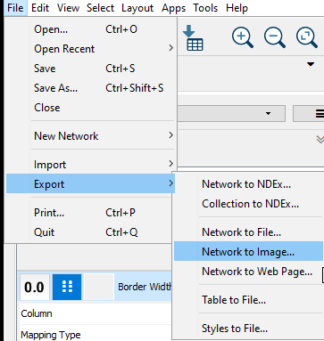

### Export

##### Export the network as an `.svg` and use a vector graphics editor like [Inkscape](https://inkscape.org/) to further fine-tune the network legend. A publication quality network might look like the one shown below.

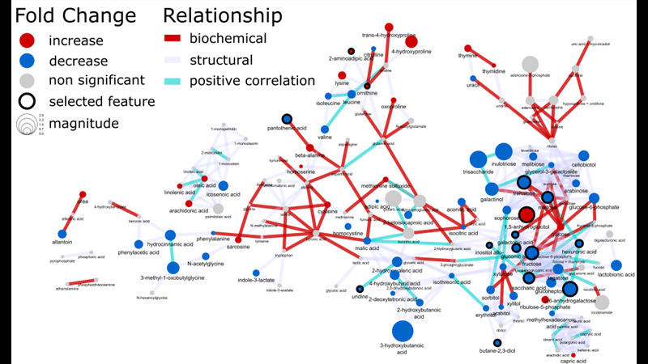